# Network data

Carole Voulgaris

9/28/2020

This week, we’ll be using a Java application called OpenTripPlanner to create isochrones (walksheds and drivesheds) from within R, using the opentripplanner package.

I’ll be using these libraries:

```r
library(osmdata)
library(opentripplanner)
library(tidyverse)
library(sf)
library(ggthemes)
library(ggspatial)
```

You’ll also need to have Java installed on your computer, since we’ll be using a Java application called Open Trip Planner.

## Load locations

I’m going to start by importing a KML file from the City of Cambridge’s Open Data Portal. This data set shows the locations of the all Cambridge Public Library locations. You can see from the results messages that this is point data with latitude/longitude coordinates, and we’ll keep them that way.

```r
CPL_libraries <- st_read(
  "https://data.cambridgema.gov/api/geospatial/kn2z-b6eg?method=export&format=KML")
```

## Get street data

Create a folder in your Repo called OTP. Within that folder, create another folder called graphs. Within *that* folder, create another folder called default. Add the OTP directory to your .gitignore file.

Next, you can run the following code (but for the area you’re analyzing) to download street network data from Open Street Map.

```r
MA_state_plane <- "+proj=lcc +lat_1=41.71666666666667 +lat_2=42.68333333333333 +lat_0=41 +lon_0=-71.5 +x_0=200000 +y_0=750000 +ellps=GRS80 +units=m +no_defs"

cambridge_street_query <- opq(bbox = 'Cambridge MA USA') %>%
  add_osm_feature(key = 'highway')

cambridge_street_query %>%
  osmdata_xml(file = 'OTP/graphs/default/cambridge_streets.osm')

cambridge_street_features <- cambridge_street_query %>%
  osmdata_sf()

cambridge_streets <- cambridge_street_features$osm_lines %>%
  st_transform(crs = MA_state_plane)
```

Verify that you now have a file in your default directory called “cambridge_streets.osm”, and try plotting the streets you’ve downloaded. You’ll notice that it isn’t clipped to the town boundaries. It includes all the roads in the rectangle (bounding box) that contains the town boundaries.

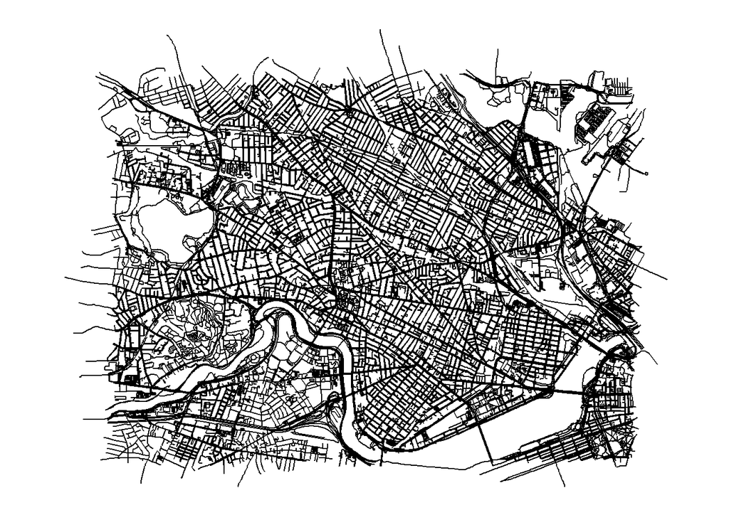

```r
ggplot(cambridge_streets) +
  geom_sf() +
  theme_map()
```

## Set up Open Trip Planner

Now we need to download a little Java utility called otp.jar and save it to the OPT directory we’ve created. You only need to run this line once, so you can delete this chunk after you run in - once you confirm that you have a file called otp.jar in your OPT directory on your computer

```r
path_otp <- otp_dl_jar("OTP")
```

```
## The OTP will be saved to OTP/otp.jar
```

Now, we’ll build a graph. This is a representation of the street and transit networks.

```r
path_data <- file.path(getwd(), "OTP")
path_otp <- paste(path_data, "otp.jar",sep = "/")

otp_build_graph(otp = path_otp, dir = path_data, memory = 1024)
```

And now we’ll launch Open Trip Planner! otp_setup may take several minutes to run.

After you do this next part, an OTP application will open in you web browser. This indicates that OpenTripPlanner is running, but other than that, you can ignore it.

```r
otp_setup(otp = path_otp, dir = path_data, memory =1024)
```

```
## 2020-09-29 17:46:25 OTP is loading and may take a while to be useable
```

```
## Router http://localhost:8080/otp/routers/default exists
```

```
## 2020-09-29 17:47:26 OTP is ready to use Go to localhost:8080 in your browser to view the OTP
```

```r
# Connect to opentripplanner
otpcon <- otp_connect()
```

```
## Router http://localhost:8080/otp/routers/default exists
```

## Create isochrones

Create isochrones for areas within a five-minute walk and a five-minute drive.

```r
iso_5min_walk <-
  otp_isochrone(otpcon = otpcon, fromPlace = CPL_libraries,
                mode = "WALK", cutoffSec = 300) %>%
  st_transform(crs = MA_state_plane) %>%
  mutate(mode = "walk")
iso_5min_drive <-
  otp_isochrone(otpcon = otpcon, fromPlace = CPL_libraries,
                mode = "CAR", cutoffSec = 300) %>%
  st_transform(crs = MA_state_plane) %>%
  mutate(mode = "drive")
iso_all_modes <- rbind(iso_5min_drive, iso_5min_walk)

otp_stop()
```

```
## [1] "SUCCESS: The process \"java.exe\" with PID 16180 has been terminated."
```

Now I can draw a map of these isochrones on a map. I’ll use a background image from OpenStreetMap as a basemap (if you do this, always, always, always give attribution to the OpenStreetMap contributors).

[figure not shown]

```r
right_side <- st_bbox(iso_all_modes)$xmax
left_side  <- st_bbox(iso_all_modes)$xmin
top_side <- st_bbox(iso_all_modes)$ymax
bottom_side <- st_bbox(iso_all_modes)$ymin

ggplot(iso_all_modes) +
  annotation_map_tile(zoomin = 0) +
  geom_sf(aes(fill = mode), alpha = 0.5) +
  #geom_sf(data = cambridge_streets) +
  geom_sf(data = CPL_libraries) +
  coord_sf(xlim = c(left_side, right_side),
           ylim = c(bottom_side, top_side), expand = FALSE) +
  scale_fill_viridis_d(name = "Area that is reachable within 5 minutes",
                       labels = c("By car", "By foot")) +
  theme_map() +
  labs(caption = "Basemap Copyright OpenStreetMap contributors")
```

Alternatively, you could just use the street network as a basemap.

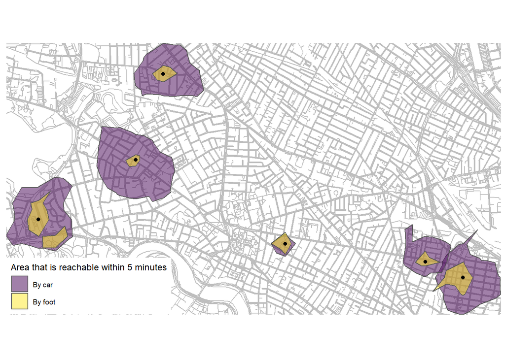

```r
ggplot(iso_all_modes) +
  geom_sf(data = cambridge_streets, color = "gray") +
  geom_sf(aes(fill = mode), alpha = 0.5) +
  geom_sf(data = CPL_libraries) +
  coord_sf(xlim = c(left_side, right_side),
           ylim = c(bottom_side, top_side), expand = FALSE) +
  scale_fill_viridis_d(name = "Area that is reachable within 5 minutes",
                       labels = c("By car", "By foot")) +
  theme_map()
```

## Calcuate and compare isochrone areas

I can use `st_area()` to calculate the area of each isochrone and visualize the relationship between the size of a walkshed and the size of a driveshed.

It’s not a flashy figure, but it is sort of interesting.

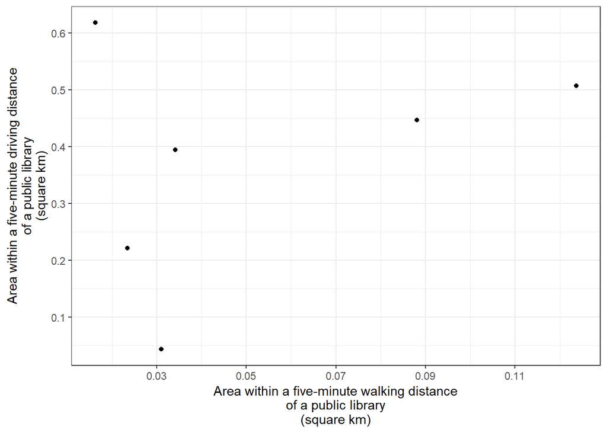

```r
iso_areas <- iso_all_modes %>%
  mutate(area = st_area(iso_all_modes)) %>%
  st_set_geometry(NULL) %>%
  pivot_wider(names_from = mode, values_from = area)

ggplot(iso_areas,
       aes(x = as.numeric(walk), y = as.numeric(drive))) +
  geom_point() +
  scale_x_continuous(name =
            "Area within a five-minute walking distance\nof a public library\n(square km)",
            breaks = breaks <- seq(10000, 130000, by = 20000),
            labels = breaks / 1000000) +
  scale_y_continuous(name =
            "Area within a five-minute driving distance\nof a public library\n(square km)",
            breaks = breaks <- seq(0, 700000, by = 100000),
            labels = breaks / 1000000) +
  theme_bw()
```